# Replication of Faber’s A Quantitative Approach to Tactical Asset Allocation - Asset Class Returns

#### Importing the data into R

Each asset’s class price series has been saved as a CSV. The packages used for performance analysis and backtesting require the data to be xts objects which are created by the following code.

```r
#remove past data
rm(list = ls(envir = globalenv()),envir = globalenv()) #clear Vars from global enviroment
#load required packages
library(PerformanceAnalytics)
library(quantstrat)
#declare symbols
symbols <- c("TBILLS","SP500","EAFE","US10YR","GSCI","NAREIT","CPI")
#use quantmod function to load data as xts objects
getSymbols(symbols,
           src = "csv",
           dir="../Data/CSV files",
           col.names=c("Close"))
```

```
[1] "TBILLS" "SP500"  "EAFE"   "US10YR" "GSCI"   "NAREIT" "CPI"
```

#### Calculating asset class returns and replicating the chart in Faber’s Figure 3

Once the data is loaded i can create one xts object for the prices and calculate each asset class’s returns. The asset class returns are then charted to replicate figure 3 on page 16.

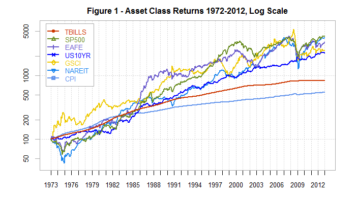

```r
#combine all closing prices into one xts file
AllAssets <- cbind.xts(Cl(TBILLS),
                       Cl(SP500),
                       Cl(EAFE),
                       Cl(US10YR),
                       Cl(GSCI),
                       Cl(NAREIT),
                       Cl(CPI))
#subset to required period
AllAssets <- AllAssets["1972-12-31::2016-12-31"]
colnames(AllAssets) <- symbols
#calculate returns and cum returns
AllAssets.ret <- Return.calculate(AllAssets)[-1,]
AllAssets.cumret <- 100*cumprod(1+ ROC(AllAssets, type = "discrete")[-1,])
SubsetPeriod <- "1972-12-31::2012-12-31"
#chart returns
chart.TimeSeries(AllAssets.cumret[SubsetPeriod],
  main = paste("Figure 1 - Asset Class Returns ",substr(SubsetPeriod,1,4),"-",substr(SubsetPeriod,13,16),", Log Scale",sep = ""),
  #lty = "2",
  ylab = "",
  ylog = TRUE,
  ylim = c(40,6000),
  date.format = "%Y",
  major.ticks = "years",
  legend.loc = "topleft",
  colorset = c("orangered3","olivedrab","slateblue","blue","gold2","dodgerblue2","cornflowerblue"), #create own colorset at some point
  minor.ticks =FALSE)
```

to do list:

- confirm colorset matches
- create same scale if possible

### Extend Asset Class Returns chart to include recent data from 2013-2016

Now by easily changing the subset dates, the code can produce a chart that includes the most recent years returns

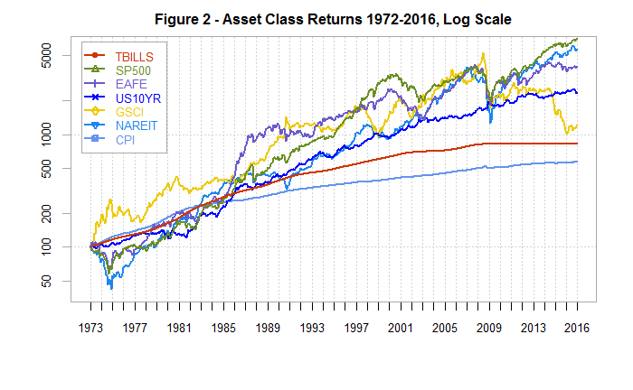

```r
SubsetPeriod <- "1972-12-31::2016-12-31"
chart.TimeSeries(AllAssets.cumret[SubsetPeriod],
  main = paste("Figure 2 - Asset Class Returns ",substr(SubsetPeriod,1,4),"-",substr(SubsetPeriod,13,16),", Log Scale",sep = ""),
  #lty = "2",
  ylab = "",
  ylog = TRUE,
  ylim = c(40,6100),
  date.format = "%Y",
  major.ticks = "years",
  legend.loc = "topleft",
  colorset = c("orangered3","olivedrab","slateblue","blue","gold2","dodgerblue2","cornflowerblue"),
  minor.ticks =FALSE)
```

### Focusing on the last 4 years of returns

The same code can be manipulated to calculate asset class returns focusing on the most recent years

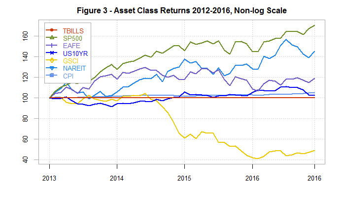

```r
#subset to required period
SubsetPeriod <- "2012-12-31::2016-12-31"
AllAssets2 <- AllAssets[SubsetPeriod]
#calculate returns and cum returns
AllAssets2.ret <- Return.calculate(AllAssets2)[-1,]
AllAssets2.cumret <- 100*cumprod(1+ ROC(AllAssets2, type = "discrete")[-1,])
#change first value to 100 - WORK OUT HOW TO ADD ADDITIONAL DATA POINT FOR 2012-12-31
AllAssets2.cumret[1:1,] <- c(100)
#chart - work out how to change x axis to 2017?
chart.TimeSeries(AllAssets2.cumret,
  main = paste("Figure 3 - Asset Class Returns ",substr(SubsetPeriod,1,4),"-",substr(SubsetPeriod,13,16),", Non-log Scale",sep = ""),
  ylab = "",
  ylog = FALSE,
  #ylim = c(0,300),
  date.format = "%Y",
  major.ticks = "years",
  legend.loc = "topleft",
  colorset = c("orangered3","olivedrab","slateblue","blue","gold2","dodgerblue2","cornflowerblue"),
  minor.ticks =FALSE)
```

todo - add 100 in first row

#### Analysing asset class returns, max drawdowns and other performance statistics

Using the package performance analytics, common performance statistics such as CAGR, volatility and sharpe ratios can be calculated. This code replicates Faber’s figure 4 on page 17

```r
#subset to required dates
SubsetPeriod <- "1972-12-31::2012-12-31"
#Create xts for Returns
Returns <- AllAssets.ret[SubsetPeriod]
#calculate statistics and store as "stats"
stats <- rbind(100*Return.annualized(Returns,scale = 12),
               100*StdDev.annualized(Returns,scale = 12),
               SharpeRatio.annualized(Returns,Rf = AllAssets.ret$TBILLS),
               100*maxDrawdown(Returns,scale = 12,invert = FALSE),
               100*c(Return.annualized(Returns$CPI,scale = 12)))
#rename table rows/column names and format
colnames(stats) <- symbols
rownames(stats) <- c("Return","Volatility",paste("Sharpe (",round(stats[1,"TBILLS"],2),"%)", sep = ""),"MaxDD","Inflation CAGR")
stats <- round(stats[,-7],2)
```

Lets print the stats:

```
               TBILLS  SP500   EAFE US10YR   GSCI NAREIT
Return           5.42   9.77   9.19   8.12   8.34   9.64
Volatility       0.95  15.71  17.60   8.47  20.55  18.16
Sharpe (5.42%)   0.00   0.26   0.20   0.30   0.13   0.22
MaxDD            0.00 -50.95 -56.40 -15.75 -67.65 -68.18
Inflation CAGR   4.33   4.33   4.33   4.33   4.33   4.33
```

To do:

#### Differences to Faber’s research performance statistics

Lets save Fabers data from Figure 4 to calculate differences from the replicated data and calcs above.

```r
FabersStats <- c(5.41,9.7,9.17,8.18,8.32,9.65,0.95,15.69,17.61,8.44,20.55,18.13,0,0.27,0.21,0.33,0.14,0.23,0,-50.95,-56.4,-15.79,-67.65,-67.88,4.3,4.3,4.3,4.3,4.3,4.3)
originalstats <- matrix(FabersStats,ncol = 6,byrow = TRUE)
colnames(originalstats) <- symbols[-7]
rownames(originalstats) <- c("Return","Volatility","Sharpe (5.41%)","MaxDD","Inflation CAGR")
```

Now lets print Faber’s Stats:

```
               TBILLS  SP500   EAFE US10YR   GSCI NAREIT
Return           5.41   9.70   9.17   8.18   8.32   9.65
Volatility       0.95  15.69  17.61   8.44  20.55  18.13
Sharpe (5.41%)   0.00   0.27   0.21   0.33   0.14   0.23
MaxDD            0.00 -50.95 -56.40 -15.79 -67.65 -67.88
Inflation CAGR   4.30   4.30   4.30   4.30   4.30   4.30
```

And print differences (replicated stats less faber):

```
               TBILLS SP500  EAFE US10YR  GSCI NAREIT
Return           0.01  0.07  0.02  -0.06  0.02  -0.01
Volatility       0.00  0.02 -0.01   0.03  0.00   0.03
Sharpe (5.42%)   0.00 -0.01 -0.01  -0.03 -0.01  -0.01
MaxDD            0.00  0.00  0.00   0.04  0.00  -0.30
Inflation CAGR   0.03  0.03  0.03   0.03  0.03   0.03
```

#### Extending the performance stats to include the years 2013-2016

```r
#subset to required dates
Returns <- AllAssets.ret["1972-12-31::2016-12-31"]
currentstats <- rbind(100*Return.annualized(Returns,scale = 12),
               100*StdDev.annualized(Returns,scale = 12),
               SharpeRatio.annualized(Returns,Rf = AllAssets.ret$TBILLS),
               100*maxDrawdown(Returns,scale = 12,invert = FALSE),
               100*c(Return.annualized(Returns$CPI,scale = 12)))
colnames(currentstats) <- symbols
rownames(currentstats) <- c("Return","Volatility",paste("Sharpe (",round(stats[1,"TBILLS"],2),"%)", sep = ""),"MaxDD","Inflation CAGR")
currentstats <- round(currentstats[,-7],2)
currentstats
```

```
               TBILLS  SP500   EAFE US10YR   GSCI NAREIT
Return           4.93  10.18   8.75   7.41   5.85   9.65
Volatility       1.00  15.30  17.21   8.33  20.52  17.81
Sharpe (5.42%)   0.00   0.33   0.21   0.28   0.04   0.25
MaxDD            0.00 -50.95 -56.40 -15.75 -80.90 -68.18
Inflation CAGR   4.04   4.04   4.04   4.04   4.04   4.04
```

```r
#write.table(currentstats, "clipboard", sep="\t", col.names=NA) #copies to clipboad for word/excel
```

Lets look at the changes from the last 4 years:

```r
stats
```

```
               TBILLS  SP500   EAFE US10YR   GSCI NAREIT
Return           5.42   9.77   9.19   8.12   8.34   9.64
Volatility       0.95  15.71  17.60   8.47  20.55  18.16
Sharpe (5.42%)   0.00   0.26   0.20   0.30   0.13   0.22
MaxDD            0.00 -50.95 -56.40 -15.75 -67.65 -68.18
Inflation CAGR   4.33   4.33   4.33   4.33   4.33   4.33
```

```r
currentstats
```

```
               TBILLS  SP500   EAFE US10YR   GSCI NAREIT
Return           4.93  10.18   8.75   7.41   5.85   9.65
Volatility       1.00  15.30  17.21   8.33  20.52  17.81
Sharpe (5.42%)   0.00   0.33   0.21   0.28   0.04   0.25
MaxDD            0.00 -50.95 -56.40 -15.75 -80.90 -68.18
Inflation CAGR   4.04   4.04   4.04   4.04   4.04   4.04
```

```r
currentstats-stats
```

```
               TBILLS SP500  EAFE US10YR   GSCI NAREIT
Return          -0.49  0.41 -0.44  -0.71  -2.49   0.01
Volatility       0.05 -0.41 -0.39  -0.14  -0.03  -0.35
Sharpe (5.42%)   0.00  0.07  0.01  -0.02  -0.09   0.03
MaxDD            0.00  0.00  0.00   0.00 -13.25   0.00
Inflation CAGR  -0.29 -0.29 -0.29  -0.29  -0.29  -0.29
```

```r
round(100*(currentstats/stats-1),2)
```

```
               TBILLS SP500  EAFE US10YR   GSCI NAREIT
Return          -9.04  4.20 -4.79  -8.74 -29.86   0.10
Volatility       5.26 -2.61 -2.22  -1.65  -0.15  -1.93
Sharpe (5.42%)    NaN 26.92  5.00  -6.67 -69.23  13.64
MaxDD             NaN  0.00  0.00   0.00  19.59   0.00
Inflation CAGR  -6.70 -6.70 -6.70  -6.70  -6.70  -6.70
```